# Eye-Tracking Analysis Tutorial

Dan Mirman

24 January 2019

## Workshop Schedule

Day 1: Data wrangling, Pre-processing eye-tracking data

Day 2: Statistical analysis of eye-tracking data (GCA)

| Time | Content |
| --- | --- |
| 9am - 10am | GCA basics |
| 10am - 11:15am | Modeling non-linear change |
| 11:15 - Noon | Within-subjects effects |
| Noon - 1:00pm | Lunch break, Q&A, own data analysis time |
| 1:00pm - 1:45pm | Logistic GCA |
| 1:45pm - 2:30pm | Visualizing higher-order polynomial terms |
| 2:30pm - 3:15pm | Break, own data analysis time |
| 3:15pm - 4:15pm | Quantifying and analyzing individual differences |
| 4:15pm - 5pm | Own data analysis time |

## What are time course data?

- Longitudinal data
- Repeated observations
- Example: Height tracking
- Specific case of “repeated measures” or “nested” data

## Two key features

**Nested data are not independent**

- A child that is taller-than-average at time *t*, is likely to be taller-than-average at time *t+1*
- Non-independence is related to individual differences
- Nesting can happen on multiple levels: children within families or hospitals

## Two key features

**Nested data are not independent**

- A child that is taller-than-average at time *t*, is likely to be taller-than-average at time *t+1*
- Non-independence is related to individual differences
- Nesting can happen on multiple levels: children within families or hospitals

**Related by continuous variable** (i.e., time, but could be [letter] size, number of distractors, etc.)

- Ought to model this variable as continuous
- Can quantify trajectories/shapes of change

## Gradual change

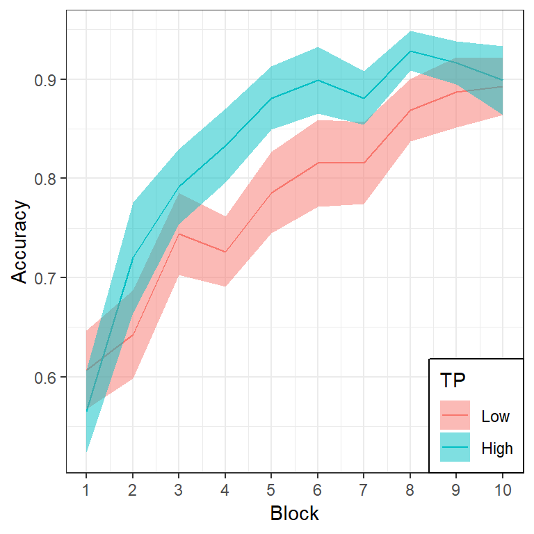

- Novel word learning is faster for high TP than low TP words
- But, t-test on overall mean accuracy is marginal (p=0.096)
- Repeated measures ANOVA shows main effect of Block, marginal effect of TP, and no interaction (F<1)
- Block-by-block t-test significant only in block 4 and marginal in block 5

## Replication crisis

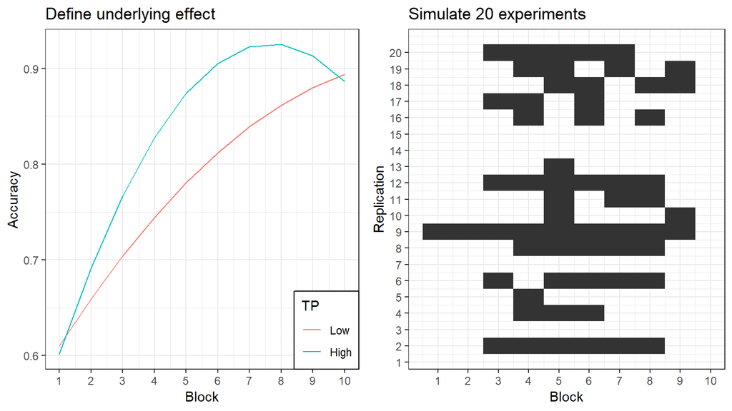

- 5/20 replications had no significant effect in any block

## Linear regression: A brief review

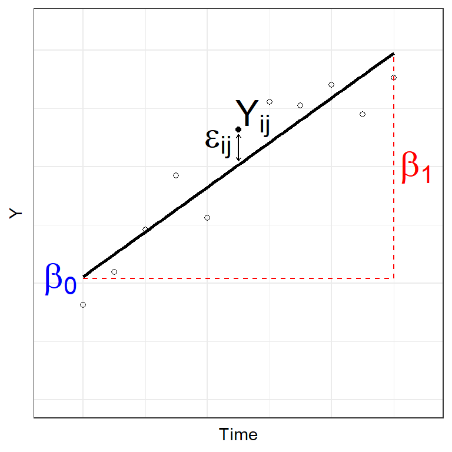

- $Y = \beta_{0} + \beta_{1} \cdot Time$
- $Y_{ij} = \beta_{0i} + \beta_{1i} \cdot Time_{j} + \epsilon_{ij}$
- **Fixed effects**: $\beta_{0}$ (Intercept), $\beta_{1}$ (Slope)
- **Random effects**: $\epsilon_{ij}$ (Residual error)

## Multilevel regression: Fixed effects

Level 1: $Y_{ij} = \beta_{0i} + \beta_{1i} \cdot Time_{j} + \epsilon_{ij}$

Level 2: model of the Level 1 parameter(s)

- $\beta_{0i} = \gamma_{00} + \zeta_{0i}$
  - $\gamma_{00}$ is the population mean
  - $\zeta_{0i}$ is individual deviation from the mean
- $\beta_{0i} = \gamma_{00} + \gamma_{0C} \cdot C + \zeta_{0i}$
  - $\gamma_{0C}$ is the fixed effect of condition $C$ on the *intercept*
- $\beta_{1i} = \gamma_{10} + \gamma_{1C} \cdot C + \zeta_{1i}$
  - $\gamma_{1C}$ is the fixed effect of condition $C$ on the *slope*

## Multilevel regression: Random effects

Level 1: $Y_{ij} = \beta_{0i} + \beta_{1i} \cdot Time_{j} + \epsilon_{ij}$

Level 2:

$\beta_{0i} = \gamma_{00} + \gamma_{0C} \cdot C + \zeta_{0i}$

$\beta_{1i} = \gamma_{10} + \gamma_{1C} \cdot C + \zeta_{1i}$

Residual errors

- $\zeta_{0i}$ unexplained variance in *intercept*
- $\zeta_{1i}$ unexplained variance in *slope*
- Unexplained variance reflects individual differences
- Random effects require a lot of data to estimate

## Fixed vs. Random effects

**Fixed effects**

- Interesting in themselves
- Reproducible fixed properties of the world (nouns vs. verbs, WM load, age, etc.)
- *Unique, unconstrained parameter estimate for each condition*

**Random effects**

- Randomly sampled observational units over which you intend to generalize (particular nouns/verbs, particular individuals, etc.)
- Unexplained variance
- *Drawn from normal distribution with mean 0*

## Maximum Likelihood Estimation

- Find an estimate of parameters that maximizes the likelihood of observing the actual data
- Simple regression: OLS produces MLE parameters by solving an equation
- Multilevel regression: use iterative algorithm to gradually converge to MLE estimates
- Goodness of fit measure: log likelihood (LL)
  - Not inherently meaningful (unlike $R^2$)
  - Change in LL indicates improvement of the fit of the model
  - Changes in $-2LL$ (aka “Likelihood Ratio”“) are distributed as $\chi^2$
  - Requires models be nested (parameters added or removed)
  - DF = number of parameters added

## A simple (linear) GCA example

```r
library(gazer)
load("VisualSearchEx.rda") # not in gazer package
summary(VisualSearchEx)
```

```
##   Participant        Dx        Set.Size          RT
##  0042   :  4   Aphasic:60   Min.   : 1.0   Min.   :  414
##  0044   :  4   Control:72   1st Qu.: 4.0   1st Qu.: 1132
##  0083   :  4                Median :10.0   Median : 1814
##  0166   :  4                Mean   :12.8   Mean   : 2261
##  0186   :  4                3rd Qu.:18.8   3rd Qu.: 2808
##  0190   :  4                Max.   :30.0   Max.   :12201
##  (Other):108
```

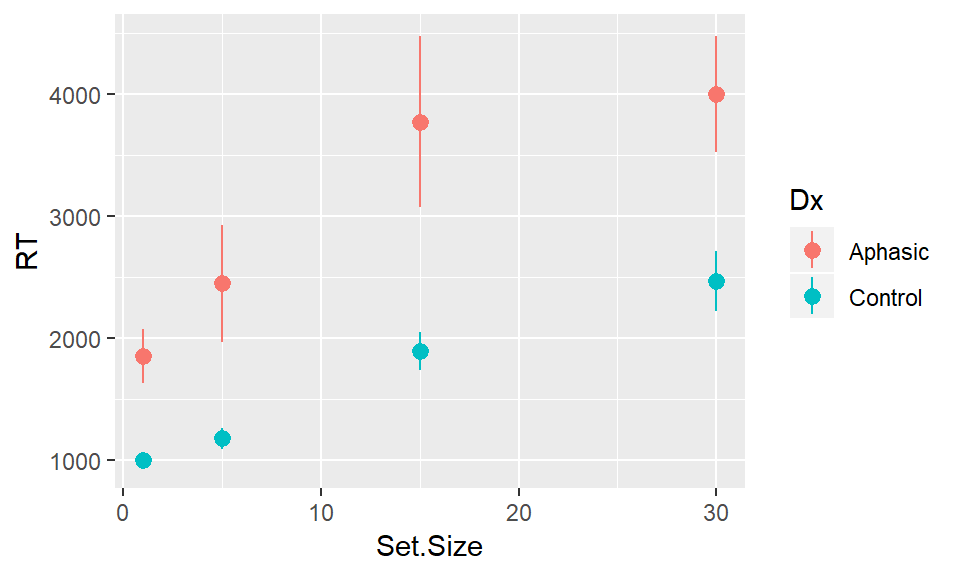

```r
ggplot(VisualSearchEx, aes(Set.Size, RT, color=Dx)) +
  stat_summary(fun.data=mean_se, geom="pointrange")
```

## A simple (linear) GCA example: Fit the models

```r
library(lme4)
# a null, intercept-only model
vs.null <- lmer(RT ~ 1 + (Set.Size | Participant), data=VisualSearchEx, REML=FALSE)
# add effect of set size
vs <- lmer(RT ~ Set.Size + (Set.Size | Participant), data=VisualSearchEx, REML=F)
# add effect of diagnosis
vs.0 <- lmer(RT ~ Set.Size + Dx + (Set.Size | Participant), data=VisualSearchEx, REML=F)
# add set size by diagnosis interaction
vs.1 <- lmer(RT ~ Set.Size * Dx + (Set.Size | Participant), data=VisualSearchEx, REML=F)
# compare model fits
anova(vs.null, vs, vs.0, vs.1)
```

```
## Data: VisualSearchEx
## Models:
## vs.null: RT ~ 1 + (Set.Size | Participant)
## vs: RT ~ Set.Size + (Set.Size | Participant)
## vs.0: RT ~ Set.Size + Dx + (Set.Size | Participant)
## vs.1: RT ~ Set.Size * Dx + (Set.Size | Participant)
##         Df  AIC  BIC logLik deviance Chisq Chi Df Pr(>Chisq)
## vs.null  5 2283 2297  -1136     2273
## vs       6 2248 2265  -1118     2236 36.90      1    1.2e-09 ***
## vs.0     7 2241 2261  -1114     2227  8.58      1     0.0034 **
## vs.1     8 2241 2264  -1113     2225  2.01      1     0.1567
## ---
## Signif. codes:  0 '***' 0.001 '**' 0.01 '*' 0.05 '.' 0.1 ' ' 1
```

## A simple (linear) GCA example: Interpet results

|  | Df | AIC | BIC | logLik | deviance | Chisq | Chi Df | Pr(>Chisq) |
| --- | --- | --- | --- | --- | --- | --- | --- | --- |
| vs.null | 5 | 2283 | 2297 | -1136 | 2273 | NA | NA | NA |
| vs | 6 | 2248 | 2265 | -1118 | 2236 | 36.902 | 1 | 0.0000 |
| vs.0 | 7 | 2241 | 2261 | -1114 | 2227 | 8.585 | 1 | 0.0034 |
| vs.1 | 8 | 2241 | 2264 | -1113 | 2225 | 2.006 | 1 | 0.1567 |

- Compared to null model, adding set size (`vs`) substantially improves model fit: response times are affected by number of distractors
- Adding effect of Diagnosis on intercept (`vs.0`) significantly improves model fit: stroke survivors respond more slowly than controls do
- Adding interaction of set size and Diagnosis, i.e., effect of Diagnosis on slope (`vs.1`), does not significantly improve model fit: stroke survivors are not more affected by distractors than controls are

## A simple (linear) GCA example: Inspect model

```r
summary(vs.1)
```

```
## Linear mixed model fit by maximum likelihood  ['lmerMod']
## Formula: RT ~ Set.Size * Dx + (Set.Size | Participant)
##    Data: VisualSearchEx
##
##      AIC      BIC   logLik deviance df.resid
##     2241     2264    -1113     2225      124
##
## Scaled residuals:
##    Min     1Q Median     3Q    Max
## -3.759 -0.317 -0.079  0.317  6.229
##
## Random effects:
##  Groups      Name        Variance Std.Dev. Corr
##  Participant (Intercept) 613393   783.2
##              Set.Size       380    19.5    1.00
##  Residual                756830   870.0
## Number of obs: 132, groups:  Participant, 33
##
## Fixed effects:
##                    Estimate Std. Error t value
## (Intercept)          2078.7      264.4    7.86
## Set.Size               73.5       11.2    6.54
## DxControl           -1106.1      357.9   -3.09
## Set.Size:DxControl    -21.7       15.2   -1.43
##
## Correlation of Fixed Effects:
##             (Intr) Set.Sz DxCntr
## Set.Size    -0.090
## DxControl   -0.739  0.066
## St.Sz:DxCnt  0.066 -0.739 -0.090
```

## A simple (linear) GCA example: Parameter p-values

```r
get_pvalues(vs.1) #default: normal approximation
```

```
##                    Estimate Std..Error t.value  p.normal p.normal.star
## (Intercept)         2078.75     264.36   7.863 3.775e-15           ***
## Set.Size              73.49      11.23   6.545 5.955e-11           ***
## DxControl          -1106.05     357.95  -3.090 2.002e-03            **
## Set.Size:DxControl   -21.74      15.20  -1.430 1.528e-01
```

```r
get_pvalues(vs.1, method = "KR") # alternative: Kenward-Roger approximation for DF
```

```
##                    Estimate Std..Error t.value df.KR      p.KR p.KR.star
## (Intercept)         2078.75     264.36   7.863    31 7.103e-09       ***
## Set.Size              73.49      11.23   6.545    31 2.630e-07       ***
## DxControl          -1106.05     357.95  -3.090    31 4.204e-03        **
## Set.Size:DxControl   -21.74      15.20  -1.430    31 1.628e-01
```

## A simple (linear) GCA example: Plot model fit

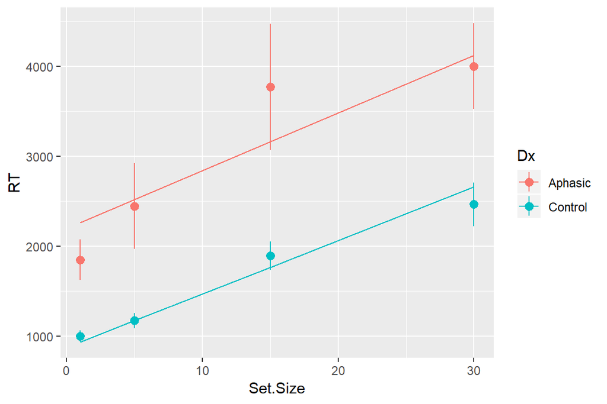

```r
ggplot(VisualSearchEx, aes(Set.Size, RT, color=Dx)) +
  stat_summary(fun.data=mean_se, geom="pointrange") +
  stat_summary(aes(y=fitted(vs.0)), fun.y=mean, geom="line")
```

## A simple (linear) GCA example: Compare model fits

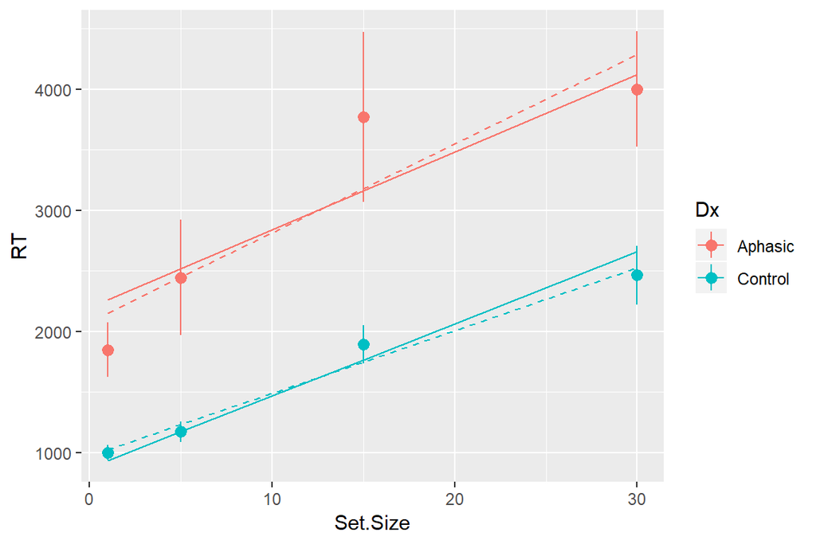

```r
ggplot(VisualSearchEx, aes(Set.Size, RT, color=Dx)) +
  stat_summary(fun.data=mean_se, geom="pointrange") +
  stat_summary(aes(y=fitted(vs.0)), fun.y=mean, geom="line") +
  stat_summary(aes(y=fitted(vs.1)), fun.y=mean, geom="line", linetype="dashed")
```

## Exercise

Analyze the recovery of object naming ability in aphasia (`NamingRecovery`)

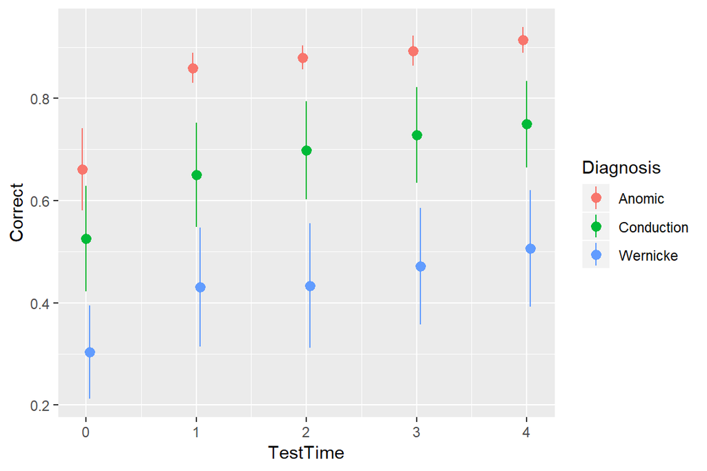

```r
ggplot(NamingRecovery, aes(TestTime, Correct, color=Diagnosis)) +
  stat_summary(fun.data=mean_se, geom="pointrange",
               position=position_dodge(width=0.1))
```

- did the patients recover any naming ability?
- did recovery differ across aphasia sub-types?

## Exercise Solution

Analyze the recovery of object naming ability in aphasia (`NamingRecovery`)

- did the patients recover any naming ability?
- did recovery differ across aphasia sub-types?

```r
nr.null <- lmer(Correct ~ 1 + (TestTime | SubjectID), data = NamingRecovery, REML=F)
nr.base <- lmer(Correct ~ TestTime + (TestTime | SubjectID), data = NamingRecovery, REML=F)
nr.0 <- lmer(Correct ~ TestTime + Diagnosis + (TestTime | SubjectID), data = NamingRecovery, REML=F)
nr.1 <- lmer(Correct ~ TestTime * Diagnosis + (TestTime | SubjectID), data = NamingRecovery, REML=F)
anova(nr.null, nr.base, nr.0, nr.1)
```

```
## Data: NamingRecovery
## Models:
## nr.null: Correct ~ 1 + (TestTime | SubjectID)
## nr.base: Correct ~ TestTime + (TestTime | SubjectID)
## nr.0: Correct ~ TestTime + Diagnosis + (TestTime | SubjectID)
## nr.1: Correct ~ TestTime * Diagnosis + (TestTime | SubjectID)
##         Df  AIC  BIC logLik deviance Chisq Chi Df Pr(>Chisq)
## nr.null  5 -126 -112   67.8     -136
## nr.base  6 -146 -130   79.2     -158 22.84      1    1.8e-06 ***
## nr.0     8 -151 -129   83.6     -167  8.72      2      0.013 *
## nr.1    10 -147 -120   83.7     -167  0.26      2      0.880
## ---
## Signif. codes:  0 '***' 0.001 '**' 0.01 '*' 0.05 '.' 0.1 ' ' 1
```

```r
get_pvalues(nr.1)
```

```
##                               Estimate Std..Error t.value  p.normal
## (Intercept)                   0.733127    0.10395  7.0525 1.757e-12
## TestTime                      0.054005    0.01562  3.4584 5.433e-04
## DiagnosisConduction          -0.167822    0.13420 -1.2505 2.111e-01
## DiagnosisWernicke            -0.393292    0.13752 -2.8600 4.237e-03
## TestTime:DiagnosisConduction -0.001558    0.02016 -0.0773 9.384e-01
## TestTime:DiagnosisWernicke   -0.009332    0.02066 -0.4518 6.514e-01
##                              p.normal.star
## (Intercept)                            ***
## TestTime                               ***
## DiagnosisConduction
## DiagnosisWernicke                       **
## TestTime:DiagnosisConduction
## TestTime:DiagnosisWernicke
```